# Repeated measures ANOVA

Disclaimer: Het peer review proces voor deze toets is nog niet afgerond; daarom is deze pagina nog in concept.

# 1 Toepassing

Gebruik de *repeated measures ANOVA* om gemiddelden te vergelijken van een groep bij twee of meer herhaalde metingen of om gemiddelden van twee of meer gepaarde groepen te vergelijken.[^1]

# 2 Onderwijscasus

De opleidingsdirecteur van de bachelor Technische Natuurkunde van een universiteit hoort vanuit de opleidingscommissie dat de eerstejaars studenten de studielast van de eerste onderwijsperiode als erg hoog ervaren. Om te onderzoeken hoe deze ervaren studielast verminderd kan worden, wil hij onderzoeken hoeveel tijd de studenten per week besteden aan hun vakken. Met behulp van een vragenlijst over de studiebelasting in het eerste jaar verzamelt hij gegevens van het aantal uur per week dat eerstejaars studenten besteden aan de vakken in de eerste onderwijsperiode: Lineaire Algebra, Relativiteitstheorie en Kosmologie. Op deze manier kan hij onderzoeken of er verschillen in de tijdsbesteding aan de verschillende vakken zijn en om te bepalen van welke vakken de studielast aangepast moet worden.

Dit onderzoek vertaalt zich in de volgende combinatie van hypothesen, waarbij de nulhypothese zo geformuleerd is dat er geen effect of verschil is en de alternatieve hypothese zo geformuleerd is dat er wel een effect of verschil is.

*H<sub>0</sub>*: Het gemiddeld aantal studieuren per week van eerstejaars studenten van de bachelor Technische Natuurkunde is hetzelfde voor de drie vakken in de eerste onderwijsperiode

*H<sub>A</sub>*: Het gemiddeld aantal studieuren per week van eerstejaars studenten van de bachelor Technsiche Natuurkunde is niet hetzelfde voor de drie vakken in de eerste onderwijsperiode

# 3 Assumpties

Om een valide toetsresultaat te bereiken met de *repeated measures ANOVA* moet de data aan een aantal voorwaarden voldoen: normaliteit, sphericiteit en onafhankelijkheid.[^2] Onafhankelijkheid houdt in dat de herhaalde metingen van de deelnemers[^3] onafhankelijk van elkaar zijn.

## 3.1 Normaliteit

De assumptie van normaliteit houdt in dat er een normale verdeling van de afhankelijke variabele is in elke groep. Wanneer er duidelijke afwijkingen van normaliteit zijn, is het transformeren van de data een optie.[^4] Een andere optie is het gebruik van de nonparametrische Friedman’s ANOVA waar normaliteit geen assumptie is.[^5] Controleer de assumptie van normaliteit voor elke groep met de volgende stappen:  
1. Controleer de data visueel met een histogram, een boxplot of een Q-Q plot.  
2. Toets of de data normaal verdeeld zijn met de *Kolmogorov-Smirnov test* of bij een kleinere steekproef (n < 50) met de *Shapiro-Wilk test*.[^6]<sup>,</sup>[^7]

De eerste stap heeft als doel een goede indruk te krijgen van de verdeling van de steekproef. In de tweede stap wordt de assumptie van normaliteit getoetst. De statistische toets laat zien of de verdeling van de observaties van een groep voldoet aan de assumptie van normaliteit. Voor alle groepen moet er voldaan zijn aan de assumptie van normaliteit.

Als er niet voldaan is aan normaliteit, is het transformeren van de data een optie.[^8] Een andere optie is het gebruik van de nonparametrische Friedman’s ANOVA waar normaliteit geen assumptie is.[^9] De *repeated measures ANOVA* is echter ook een robuuste toets ten opzichte van de assumptie van normaliteit. Als elke groep een aantal observaties (*n*) heeft dat groter dan 100 is, ga er dan vanuit dat de *repeated measures ANOVA* robuust genoeg is om uit te voeren zonder dat de afhankelijke variabele een normale verdeling volgt.

## 3.2 Sphericiteit

De assumptie van sphericiteit houdt in dat de variantie van de verschilscores tussen groepen van metingen ongeveer aan elkaar gelijk zijn.[^10] In deze casus zijn dat de verschilscores tussen de drie vakken: Lineaire Algebra minus Relativiteitstheorie, Relativiteitstheorie minus Kosmologie en Kosmologie minus Lineaire Algebra. Toets deze assumptie met *Mauchly’s test*. Wanneer de data niet aan de assumptie voldoen, geeft de gewone *repeated measures ANOVA* een verkeerd resultaat. Er zijn echter correcties die gebruikt kunnen worden wanneer de data niet aan sphericiteit voldoen. Een voorbeeld van mogelijke output van *Mauchly’s test* in R is hieronder weergegeven.

[output not shown]

Bij een p-waarde < 0,05, toont *Mauchly’s test* dat de assumptie van sphericiteit geschonden is. In de output is dit te zien aan de p-waarde van 0,0051 onder `$Mauchly's Test for Sphericity`. Er zijn twee mogelijke correcties wanneer er geen sphericiteit is: de Greenhouse-Geisser (GG) en Huynh-Feldt (HF) correctie. De Greenhouse-Geisser correctie staat bekend als conservatief, wat betekent dat de correctie een relatief lage kans op een type I fout heeft. In andere woorden, het zal niet vaak gebeuren dat deze correctie een significant effect aantoont wanneer dat er in werkelijkheid niet is. De Huynh-Feldt correctie staat echter bekend als liberaal, wat betekent dat er een relatief hoge kans op een type I fout is. De teststatistiek en p-waarde van beide correcties zijn in de output te vinden onder `$Sphericity Corrections`.

Houd de volgende richtlijnen aan bij het interpreteren van de *repeated measures ANOVA* wanneer niet aan sphericiteit is voldaan:

- Wanneer beide correcties significant zijn, rapporteer de (conservatieve) Greenhouse-Geisser correctie.
- Wanneer beide correcties niet significant zijn, rapporteer de (liberale) Huynh-Feldt correctie.
- Wanneer de een significant is en de ander niet, bereken de gemiddelde p-waarde van beide correcties.
  - Wanneer deze p-waarde significant is, rapporteer dan de significante correctie.
  - Wanneer deze p-waarde niet significant is, rapporteer dan de niet significante correctie.

# 4 Effectmaat

De p-waarde geeft aan of het verschil tussen groepen van metingen significant is. De grootte van het verschil of effect is echter ook relevant. Een effectmaat is een gestandaardiseerde maat die de grootte van een effect weergeeft, zodat effecten van verschillende onderzoeken met elkaar vergeleken kunnen worden.[^11] Voor de *repeated measures ANOVA* wordt de effectmaat eta squared vaak gebruikt.

## 4.1 Eta squared

De effectmaat eta squared (*η<sup>2</sup>*) berekent de proportie van de variantie in de afhankelijke variabele die verklaard wordt door de onafhankelijke variabele. In deze casus berekent het de proportie van de variantie in het aantal uren studeren die verklaard kan worden door het vak in de eerste onderwijsperiode. Een indicatie om *η<sup>2</sup>* te interpreteren is: rond 0,01 is een klein effect, rond 0,06 is een gemiddeld effect en rond 0,14 is een groot effect.[^12]

# 5 Post-hoc toetsen

De *repeated measures ANOVA* toetst of één of meerdere van de gemiddelden anders is dan de andere gemiddelden. Voer een post-hoc toets uit om te bepalen welke groepen van metingen significant verschillen.

Gebruik een correctie voor de p-waarden, omdat er meerdere toetsen tegelijkertijd worden gebruikt. Meerdere toetsen tegelijkertijd uitvoeren verhoogt de kans dat een van de nulhypotheses onterecht wordt verworpen en er bij toeval een verband wordt ontdekt dat er niet is (type I fout). In deze toetspagina wordt de *Bonferroni correctie* gebruikt. Deze correctie past de p-waarde aan door de p-waarde te vermenigvuldigen met het aantal uitgevoerde toetsen en verlaagt hiermee de kans op een type I fout. Een andere uitleg hiervan is dat het significantieniveau gedeeld wordt door het aantal toetsen wat leidt tot een lager significantieniveau en dus een strengere toets. Er zijn ook andere opties voor een correctie op de p-waarden.[^13]

# 6 Uitvoering

Er is een dataset `dfStudieuren_technische_natuurkunde` ingeladen met het aantal studieuren van eerstejaars studenten van de bachelor Technische Natuurkunde voor de drie vakken in de eerste onderwijsperiode.

## 6.1 De data bekijken

Gebruik `<dataframe>.head()` en `<dataframe>.tail()` om de structuur van de data te bekijken.

```python
## Eerste 5 observaties
print(dfStudieuren_technische_natuurkunde.head(5))
##   Studentnummer                   Vak  Studieuren
## 0       4002847      Lineaire Algebra         9.4
## 1       4002847  Relativiteitstheorie        25.8
## 2       4002847            Kosmologie        11.1
## 3       4022007      Lineaire Algebra        14.4
## 4       4022007  Relativiteitstheorie        18.2
```

```python
## Laatste 5 observaties
print(dfStudieuren_technische_natuurkunde.tail(5))
##     Studentnummer                   Vak  Studieuren
## 235       4491882  Relativiteitstheorie        18.2
## 236       4491882            Kosmologie        10.1
## 237       4498200      Lineaire Algebra         9.0
## 238       4498200  Relativiteitstheorie        17.2
## 239       4498200            Kosmologie        12.1
```

Selecteer de drie groepen van metingen en sla deze op in een vector om deze makkelijker aan te kunnen roepen.

```python
Studieuren_lineaire_algebra = dfStudieuren_technische_natuurkunde[dfStudieuren_technische_natuurkunde['Vak'] == "Lineaire Algebra"]['Studieuren']
Studieuren_relativiteitstheorie = dfStudieuren_technische_natuurkunde[dfStudieuren_technische_natuurkunde['Vak'] == "Relativiteitstheorie"]['Studieuren']
Studieuren_kosmologie = dfStudieuren_technische_natuurkunde[dfStudieuren_technische_natuurkunde['Vak'] == "Kosmologie"]['Studieuren']
```

Inspecteer de data met `np.mean()`, `np.std()` en `len()` om meer inzicht te krijgen in de data,, door deze aan te roepen uit het `numpy` package.

```python
import numpy as np
```

```python
# Gemiddelde
print(np.mean(Studieuren_lineaire_algebra))
# Standaardafwijking
## 10.035
print(np.std(Studieuren_lineaire_algebra))
# Aantal observaties
## 2.0966699787997154
print(len(Studieuren_lineaire_algebra))
## 80
```

```python
# Gemiddelde
print(np.mean(Studieuren_relativiteitstheorie))
# Standaardafwijking
## 20.277499999999996
print(np.std(Studieuren_relativiteitstheorie))
# Aantal observaties
## 3.7678234764914347
print(len(Studieuren_relativiteitstheorie))
## 80
```

```python
# Gemiddelde
print(np.mean(Studieuren_kosmologie))
# Standaardafwijking
## 11.2675
print(np.std(Studieuren_kosmologie))
# Aantal observaties
## 2.852445222962222
print(len(Studieuren_kosmologie))
## 80
```

- Gemiddeld aantal studieuren Lineaire Algebra (standaarddeviatie): 10,04 (2,1). *n* = 80
- Gemiddeld aantal studieuren Relativiteitstheorie (standaarddeviatie): 20,28 (3,77). *n* = 80.
- Gemiddeld aantal studieuren Kosmologie (standaarddeviatie): 11,27 (2,85). *n* = 80.

## 6.2 Visuele inspectie van normaliteit

Geef de verdeling van de studieuren voor elke groep visueel weer met een histogram, Q-Q plot en boxplot.

### 6.2.1 Histogram

Focus bij het analyseren van een histogram[^14] op de symmetrie van de verdeling, de hoeveelheid toppen (modaliteit) en mogelijke uitbijters. Een normale verdeling is symmetrisch, heeft één top en geen uitbijters.[^15]<sup>,</sup>[^16]

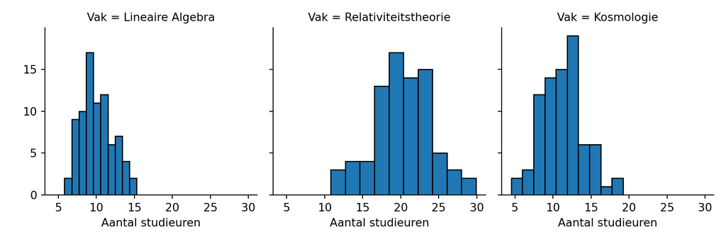

```python
# Laad seaborn of facets te maken
import seaborn as sb
# Laad matplotlib.pyplot om plots te maken
import matplotlib.pyplot as plt

# Maak een facet plot met een histogram voor elke vooropleiding
g = sb.FacetGrid(dfStudieuren_technische_natuurkunde, col="Vak")
g = (g.map(plt.hist, "Studieuren", edgecolor = "black").set_axis_labels("Aantal studieuren"))
plt.show()
```

Alle drie de verdelingen hebben één top en lijken geen uitbijters te hebben. Tevens zijn de verdelingen redelijk symmetrisch. Deze verdelingen benaderen de normaalverdeling.

### 6.2.2 Q-Q plot

Importeer `scipy.stats` om een Q-Q plot te maken. Gebruik de functie `scipy.stats.probplot()` om een Q-Q plot te maken.

Als over het algemeen de meeste datapunten op de lijn liggen, neem dan aan dat de data normaal verdeeld zijn.

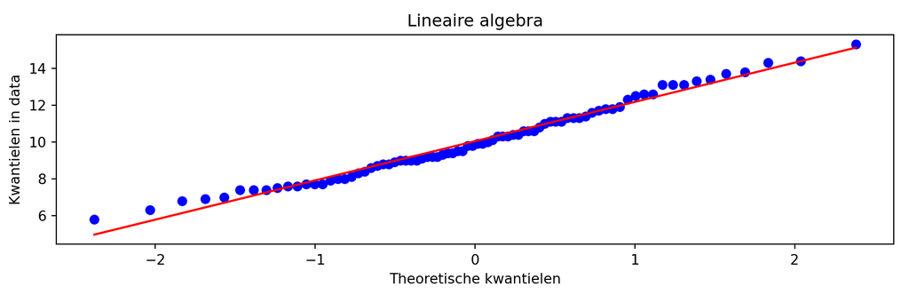

```python
import scipy.stats as stats
qq = stats.probplot(Studieuren_lineaire_algebra, dist="norm", plot=plt)
title = plt.title("Lineaire algebra")
xlab = plt.xlabel("Theoretische kwantielen")
ylab = plt.ylabel("Kwantielen in data")
plt.show()
```

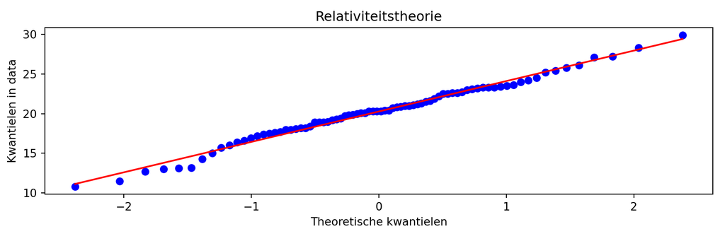

```python
import scipy.stats as stats
qq = stats.probplot(Studieuren_relativiteitstheorie, dist="norm", plot=plt)
title = plt.title("Relativiteitstheorie")
xlab = plt.xlabel("Theoretische kwantielen")
ylab = plt.ylabel("Kwantielen in data")
plt.show()
```

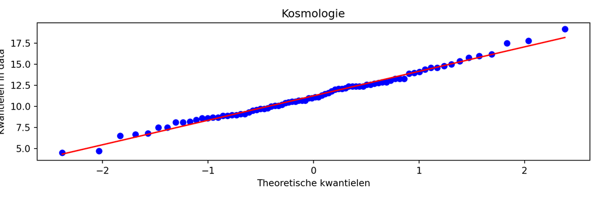

```python
import scipy.stats as stats
qq = stats.probplot(Studieuren_kosmologie,
dist="norm",
plot=plt)
title = plt.title("Kosmologie")
xlab = plt.xlabel("Theoretische kwantielen")
ylab = plt.ylabel("Kwantielen in data")
plt.show()
```

Bij alle drie de Q-Q plots liggen de punten rond de lijn die normaliteit aangeeft; vermoedelijk zijn de studieuren voor elke groep normaal verdeeld.

### 6.2.3 Boxplot

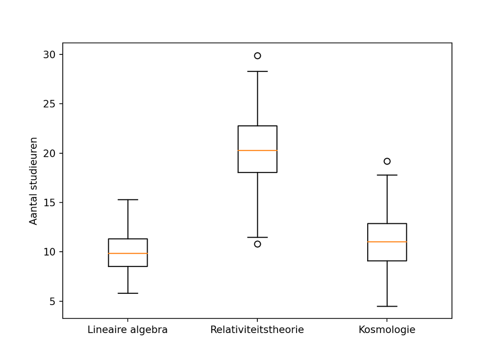

```python
fig, ax = plt.subplots()
box = ax.boxplot([Studieuren_lineaire_algebra, Studieuren_relativiteitstheorie, Studieuren_kosmologie], labels = ["Lineaire algebra", "Relativiteitstheorie", "Kosmologie"])
title = plt.title("")
ylab = plt.ylabel("Aantal studieuren")
plt.show()
```

De boxplotten geven de spreiding weer van het aantal studieuren voor de drie vakken in de eerste onderwijsperiode: Kosmologie, Lineaire Algebra en Relativiteitstheorie. In het algemeen lijken de vakken een symmetrische verdeling te hebben. De medianen van Kosmologie en Lineaire Algebra liggen een stuk lager dan de mediaan van Relativiteitstheorie. Kosmologie en Relativiteitstheorie hebben mogelijke uitbijters.

## 6.3 Toetsen van normaliteit

Om te controleren of de verdelingen van de studieuren voor elk vak normaal verdeeld zijn, kan de normaliteit getoetst worden. Twee veelgebruikte toetsen zijn: de *Kolmogorov-Smirnov test* en de *Shapiro-Wilk test*.

### 6.3.1 Kolmogorov-Smirnov

De *Kolmogorov-Smirnov test* toetst het verschil tussen twee verdelingen. Standaard toetst deze test het verschil tussen een normale verdeling en de verdeling van de steekproef. De Lilliefors correctie is vereist als het gemiddelde en de standaardafwijking niet van tevoren bekend of bepaald zijn, wat meestal het geval is bij een steekproef. Als de p-waarde kleiner dan 0,05 is, is de verdeling van de data significant verschillend van de normale verdeling.

De standaard interpretatie van een statitische toets in Python is: `(<teststatistiek>, <p-waarde>)`. Verder toetst Python standaard tweezijdig.

```python
import statsmodels.stats.api as smod
```

```python
print(smod.lilliefors(Studieuren_lineaire_algebra, pvalmethod="table"))
```

```
## (0.07508484599029996, 0.3894604568778973)
```

```python
print(smod.lilliefors(Studieuren_relativiteitstheorie, pvalmethod="table"))
```

```
## (0.058189080145924776, 0.7746392654328548)
```

```python
print(smod.lilliefors(Studieuren_kosmologie, pvalmethod="table"))
```

```
## (0.05336196365029733, 0.8701992388189942)
```

De p-waarde is groter dan 0,05 voor elk vak; er is geen significant verschil gevonden tussen de verdeling van de steekproef en de normale verdeling. [^19] De *repeated measures ANOVA* kan uitgevoerd worden.

### 6.3.2 Shapiro-Wilk Test

De *Shapiro-Wilk test* is een soortgelijke toets als de *Kolmogorov-Smirnov test* en vooral geschikt bij kleine steekproeven (n < 50). Als de p-waarde kleiner dan 0,05 is, is de verdeling van de data significant verschillend van de normale verdeling.

```python
import scipy.stats as stats
print(stats.shapiro(Studieuren_lineaire_algebra))
```

```
## ShapiroResult(statistic=0.9812197089195251, pvalue=0.2889765799045563)
```

```python
import scipy.stats as stats
print(stats.shapiro(Studieuren_relativiteitstheorie))
```

```
## ShapiroResult(statistic=0.988277018070221, pvalue=0.6830300688743591)
```

```python
import scipy.stats as stats
print(stats.shapiro(Studieuren_kosmologie))
```

```
## ShapiroResult(statistic=0.990877091884613, pvalue=0.8474676012992859)
```

De p-waarde is groter dan 0,05 voor elk vak, dus er is geen significant verschil gevonden tussen de verdeling van de steekproef en de normale verdeling.[^20] De *repeated measures ANOVA* kan uitgevoerd worden.

## 6.4 Repeated measures ANOVA

Voer de *repeated measures ANOVA* uit om de vraag te beantwoorden of er verschillen zijn tussen het aantal studieuren voor de vakken in de eerste onderwijsperiode van het eerste jaar van de bachelor Technische Natuurkunde. Gebruik de functie `rm_anova` van het package `pingouin` met als argumenten de dataset `dfStudieuren_technische_natuurkunde`, de afhankelijke variabele `dv = 'Studieuren'`, de onafhankelijke variabele `within = 'Vak'`, de variabele die de observaties aangeeft `subject = 'Studentnummer'`, `correction = True` om ook *Mauchly’s test* uit te voeren en de resultaten voor de Greenhouse-Geisser correctie te laten, en `effsize = 'n2'` om *eta squared* als effectmaat te gebruiken.

```python
# Importeer package pingouin
import pingouin as pg

# Voer de repeated measures ANOVA uit
aov = pg.rm_anova(data = dfStudieuren_technische_natuurkunde,
dv = 'Studieuren',
within = 'Vak',
subject = 'Studentnummer',
correction = True,
effsize = 'n2')

# Print de resultaten van repeated measures ANOVA. Omdat de output veel kolommen heeft, wordt het in twee helften geprint zodat alles zichtbaar is in de output
print(aov.iloc[:,:7])
```

```
##   Source  ddof1  ddof2           F         p-unc     p-GG-corr        n2
## 0    Vak      2    158  297.766261  2.528435e-54  8.614008e-53  0.700566
```

```python
print(aov.iloc[:,7:])
```

```
##         eps  sphericity   W-spher   p-spher
## 0  0.970274        True  0.969363  0.297149
```

## 6.5 Post-hoc toets

Voer post-hoc toetsen uit om te onderzoeken welke vakken uit de eerste onderwijsperiode van elkaar verschillen wat betreft het aantal studieuren dat eerstejaars studenten van de bachelor Technische Natuurkunde hieraan besteden. Bereken eerst de verschillen in gemiddelde tussen de drie vakken. Gebruik daarna voor de post-hoc toetsen de functie `pairwise_ttests` van het `pingouin` package met als argumenten de dataset `data = dfStudieuren_technische_natuurkunde`, de afhankelijke variabele `dv = 'Studieuren'`, de onafhankelijke variabele `within = 'Vak'`, de variabele die de observaties aangeeft `subject = 'Studentnummer'`, de methode om te corrigeren voor meerdere toetsen (Bonferroni) `padjust = 'bonf`’ en `parametric = True` om aan te geven dat er een parametrische toets (de t-toets) gebruikt moet worden.

```python
# Bereken de verschillen in gemiddelde tussen de drie vakken
Verschil_gemiddelde_LA_RT = np.mean(Studieuren_lineaire_algebra) - np.mean(Studieuren_relativiteitstheorie)
Verschil_gemiddelde_RT_KL = np.mean(Studieuren_relativiteitstheorie) - np.mean(Studieuren_kosmologie)
Verschil_gemiddelde_KL_LA = np.mean(Studieuren_kosmologie) - np.mean(Studieuren_lineaire_algebra)

# Voer de post-hoc toetsen uit
post_hoc = pg.pairwise_ttests(data = dfStudieuren_technische_natuurkunde,
dv = 'Studieuren',
within = 'Vak',
subject = 'Studentnummer',
padjust = 'bonf',
parametric = True)

# Print de benodigde resultaten
print(post_hoc[['A', 'B', 'T', 'p-corr']])
```

```
##                   A                     B          T        p-corr
## 0        Kosmologie      Lineaire Algebra   2.959493  1.219685e-02
## 1        Kosmologie  Relativiteitstheorie -18.987592  1.069069e-30
## 2  Lineaire Algebra  Relativiteitstheorie -21.290292  5.453525e-34
```

# 7 Rapportage

| Opleiding | M | SD | N |
| --- | --- | --- | --- |
| Lineaire Algebra | 10,04 | 2,1 | 80 |
| Relativiteitstheorie | 20,28 | 3,77 | 80 |
| Kosmologie | 11,27 | 2,85 | 80 |

*Tabel 1. Het gemiddelde aantal studieuren, bijbehorende standaarddeviatie en groepsgrootte voor de vakken in de eerste onderwijsperiode van de bachelor Technische Natuurkunde.*

Deze pagina maakt onderdeel uit van het Statistisch Handboek Studiedata, ontwikkeld binnen de zone Veilig en betrouwbaar benutten van studiedata van het Versnellingsplan. R code is uitgevoerd met R versie 4.2.2; Python code is uitgevoerd in Python 3.6.13. De gesimuleerde datasets zijn hier te downloaden.  
© 2023 [Versnellingsplan](https://www.versnellingsplan.nl) - Statistisch Handboek Studiedata - Licentie Laatst gewijzigd op:18-01-2023

[^1]: Universiteit van Amsterdam (26 augustus 2014). *Repeated-Measures ANOVA*. [UvA Wiki Methodologiewinkel](https://wiki.uva.nl/methodologiewinkel/index.php/Repeated-Measures_ANOVA).
[^2]: Universiteit van Amsterdam (26 augustus 2014). *Repeated-Measures ANOVA*. [UvA Wiki Methodologiewinkel](https://wiki.uva.nl/methodologiewinkel/index.php/Repeated-Measures_ANOVA).
[^3]: Met een deelnemer wordt het object bedoeld dat geobserveerd wordt, bijvoorbeeld een student, een inwoner van Nederland, een opleiding of een organisatie. Met een observatie wordt de waarde bedoeld die de deelnemer heeft voor een bepaalde variabele. Een deelnemer heeft dus meestal een observatie voor meerdere variabelen.
[^4]: Er zijn verschillende opties om variabelen te transformeren, zoals de logaritme, wortel of inverse (1 gedeeld door de variabele) nemen van de variabele. Zie *Discovering statistics using IBM SPSS statistics* van Field (2013) pagina 201-210 voor meer informatie over welke transformaties wanneer gebruikt kunnen worden.
[^5]: Allen, P. & Bennett, K. (2012). *SPSS A practical Guide version 20.0*. Cengage Learning Australia Pty Limited.
[^6]: Laerd statistics (2018). *Testing for Normality using SPSS Statistics*. https://statistics.laerd.com/spss-tutorials/testing-for-normality-using-spss-statistics.php.
[^7]: Universiteit van Amsterdam (14 juli 2014). *Normaliteit*. [UvA Wiki Methodologiewinkel](https://wiki.uva.nl/methodologiewinkel/index.php/Normaliteit).
[^8]: Er zijn verschillende opties om variabelen te transformeren, zoals de logaritme, wortel of inverse (1 gedeeld door de variabele) nemen van de variabele. Zie *Discovering statistics using IBM SPSS statistics* van Field (2013) pagina 201-210 voor meer informatie over welke transformaties wanneer gebruikt kunnen worden.
[^9]: Allen, P. & Bennett, K. (2012). *SPSS A practical Guide version 20.0*. Cengage Learning Australia Pty Limited.
[^10]: Field, A., Miles, J., & Field, Z. (2012). *Discovering statistics using R*. London: Sage publications.
[^11]: Field, A., Miles, J., & Field, Z. (2012). *Discovering statistics using R*. London: Sage publications.
[^12]: Allen, P. & Bennett, K. (2012). *SPSS A practical Guide version 20.0*. Cengage Learning Australia Pty Limited.
[^13]: Field, A., Miles, J., & Field, Z. (2012). *Discovering statistics using R*. London: Sage publications.
[^14]: De breedte van de staven van het histogram wordt vaak automatisch bepaald, maar kan handmatig aangepast worden. Aangezien de breedte van de staven bepalend zijn voor de indruk die de visualisatie geeft, is het verstandig om hier goed op te letten.
[^15]: Outliers (13 augustus 2016). [UvA Wiki Methodologiewinkel](https://wiki.uva.nl/methodologiewinkel/index.php/Outliers).
[^16]: Uitbijters kunnen bepalend zijn voor de uitkomst van toetsen. Bekijk of de uitbijters valide uitbijters zijn en niet een meetfout of op een andere manier incorrect verkregen data. Het weghalen van uitbijters kan de uitkomst ook vertekenen, daarom is het belangrijk om verwijderde uitbijters te melden in een rapport.
[^17]: Outliers (13 augustus 2016). [UvA Wiki Methodologiewinkel](https://wiki.uva.nl/methodologiewinkel/index.php/Outliers).
[^18]: Uitbijters kunnen bepalend zijn voor de uitkomst van toetsen. Bekijk of de uitbijters valide uitbijters zijn en niet een meetfout of op een andere manier incorrect verkregen data. Het weghalen van uitbijters kan de uitkomst ook vertekenen, daarom is het belangrijk om verwijderde uitbijters te melden in een rapport.
[^19]: In dit voorbeeld wordt uitgegaan van een waarschijnlijkheid van 95% c.q. een p-waardegrens van 0,05. De grens is naar eigen inzicht aan te passen; houd hierbij rekening met type I en type II fouten.
[^20]: In dit voorbeeld wordt uitgegaan van een waarschijnlijkheid van 95% c.q. een p-waardegrens van 0,05. De grens is naar eigen inzicht aan te passen; houd hierbij rekening met type I en type II fouten.
[^21]: In dit voorbeeld wordt uitgegaan van een waarschijnlijkheid van 95% c.q. een p-waardegrens van 0,05. De grens is naar eigen inzicht aan te passen; houd hierbij rekening met type I en type II fouten.